# profilepoint analysis Till in general

fabian gruber

October 24, 2017

How do those points that were classified correctly by the geologic map differ from those identified by the surveyors?

0 1 63 87 [1] “OBB error with all predictors of allpreds is 0.253333333333333” [1] “OBB error with all predictors of roughness is 0.313333333333333” [1] “OBB error with all predictors of localterrain is 0.34”

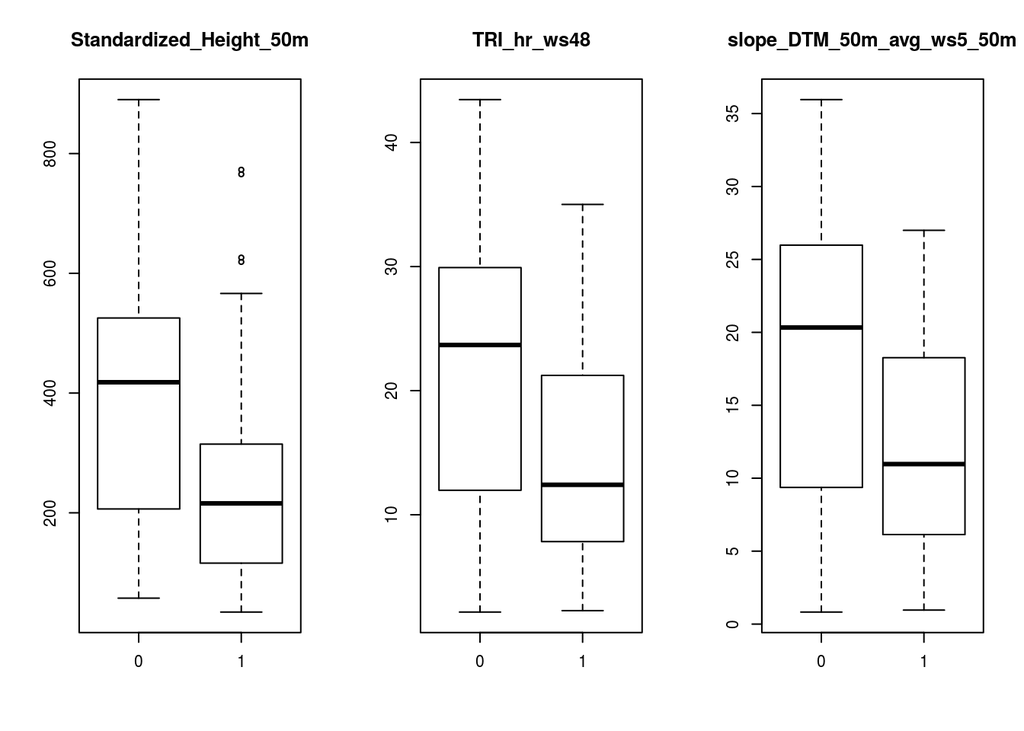

How are these points morphometrically different from others For instance different to calcareous sedimentary rock

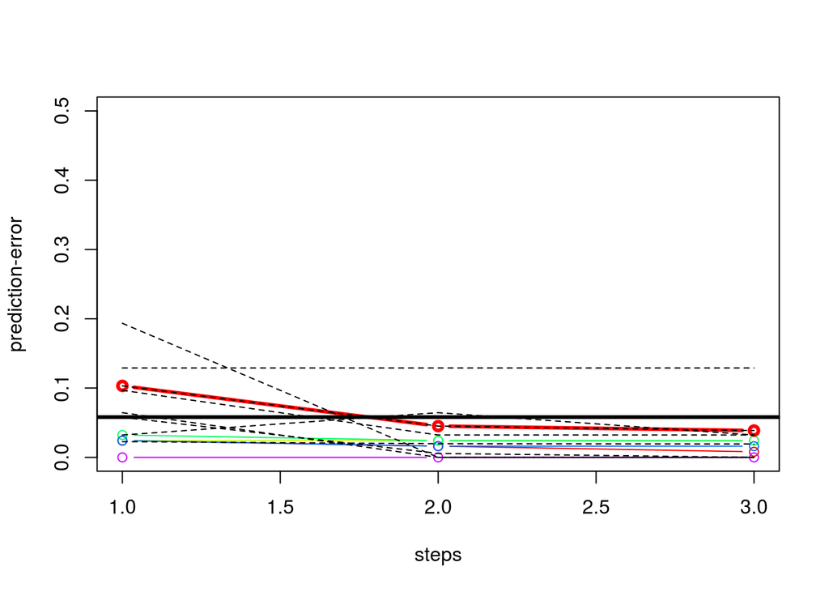

[1] “Prediction error at end is: 0.103225806451613” [2] “Prediction error at end is: 0.0451612903225806” [3] “Prediction error at end is: 0.0387096774193548”

| k 1 | k 2 | k 3 | k 4 | k 5 |
| --- | --- | --- | --- | --- |
| SlopeHeight_10m | Standardized_Height_50m | geom_hr_L50m_fl1_rplipdominance_UE_hr_20cells_hr | ChannelNetworkBaseLevel_10m | crosc_ws3_10m |
| geom_hr_L3_fl1_rpliprichness_UE_hr_5cells_hr | geom_hr_L50m_fl10_rplippatchdensity_UE_hr_40cells_hr | terraintexture_hr_ws21_tp5 | planc_ws13_hr_hr | crosc_ws7_10m |
| geom_hr_L3_fl10_rplipmps_UE_hr_20cells_hr | longc_ws23_hr_hr | PlanCurvature_10m | geom_hr_L3_fl10_rpliprichness_UE_hr_20cells_hr | slope_ws3_10m |

[1] “OBB error with all predictors of allpreds is 0.032258064516129”

|  | CSR | TG | MeanDecreaseAccuracy | MeanDecreaseGini |
| --- | --- | --- | --- | --- |
| slope_DTM_50m_avg_ws11_50m | 0.0076667 | 0.0006923 | 0.0009075 | 0.1197945 |
| minic_ws29_hr_hr | 0.0026667 | 0.0008185 | 0.0009054 | 0.0816748 |
| slope_DTM_50m_avg_ws9_50m | 0.0040000 | 0.0006754 | 0.0007659 | 0.1290948 |
| SlopeHeight_10m | 0.0060000 | 0.0003638 | 0.0006287 | 0.3011235 |
| TRI_hr_ws43 | 0.0000000 | 0.0005317 | 0.0005163 | 0.0733947 |
| TRI_hr_ws49 | -0.0010000 | 0.0005624 | 0.0005140 | 0.1066585 |
| FlowLineCurvature_10m | 0.0023333 | 0.0003917 | 0.0004741 | 0.0232538 |
| TRI_hr_ws50 | 0.0071667 | 0.0002408 | 0.0004182 | 0.0794029 |
| profc_ws3_10m | 0.0000000 | 0.0004017 | 0.0003938 | 0.0511700 |
| vectorruggedness_hr_ws59 | 0.0000000 | 0.0004049 | 0.0003937 | 0.0102500 |

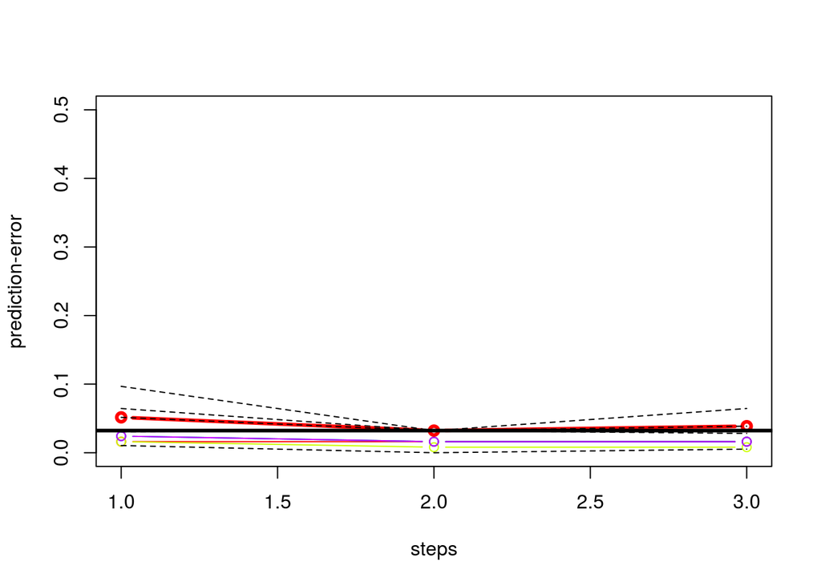

[1] “Prediction error at end is: 0.0516129032258065” [2] “Prediction error at end is: 0.032258064516129” [3] “Prediction error at end is: 0.0387096774193548”

| k 1 | k 2 | k 3 | k 4 | k 5 |
| --- | --- | --- | --- | --- |
| TRI_hr_ws22 | geom_hr_L3_fl10_rplippatchdensity_UE_hr_20cells_hr | terraintexture_hr_ws37_tp5 | geom_hr_L3_fl10_rplipedgedensity_UE_hr_40cells_hr | geom_hr_L50m_fl10_rplippatchdensity_UE_hr_40cells_hr |
| geom_hr_L50m_fl10_rplippatchdensity_UE_hr_40cells_hr | geom_hr_L3_fl1_rplipmps_UE_hr_5cells_hr | geom_hr_L3_fl10_rplipmps_UE_hr_20cells_hr | geom_hr_L50m_fl10_rplippatchdensity_UE_hr_40cells_hr | geom_hr_L3_fl10_rplipshannon_UE_hr_40cells_hr |
| geom_hr_L50m_fl10_rplippatchnum_UE_hr_40cells_hr | geom_hr_L3_fl1_rpliprichness_UE_hr_40cells_hr | geom_hr_L3_fl10_rplippatchdensity_UE_hr_20cells_hr | geom_hr_L50m_fl10_rplippatchnum_UE_hr_40cells_hr | geom_hr_L3_fl1_rpliprichness_UE_hr_5cells_hr |

[1] “OBB error with all predictors of roughness is 0.0387096774193548”

|  | CSR | TG | MeanDecreaseAccuracy | MeanDecreaseGini |
| --- | --- | --- | --- | --- |
| TRI_hr_ws31 | 0.0013333 | 0.0030520 | 0.0029066 | 0.1022264 |
| TRI_hr_ws29 | -0.0020000 | 0.0025655 | 0.0023280 | 0.1123551 |
| TRI_hr_ws25 | -0.0006667 | 0.0022606 | 0.0021801 | 0.0955671 |
| TRI_hr_ws46 | 0.0028333 | 0.0021023 | 0.0021045 | 0.1465222 |
| TRI_hr_ws35 | 0.0000000 | 0.0021511 | 0.0020939 | 0.0925547 |
| TRI_hr_ws27 | -0.0023333 | 0.0020859 | 0.0019403 | 0.0921630 |
| TRI_hr_ws20 | 0.0000000 | 0.0016287 | 0.0015933 | 0.0679068 |
| TRI_hr_ws24 | 0.0000000 | 0.0016127 | 0.0015863 | 0.0875266 |
| TRI_hr_ws32 | -0.0036667 | 0.0016931 | 0.0015485 | 0.0960332 |
| TRI_hr_ws34 | -0.0080000 | 0.0016581 | 0.0014354 | 0.0906489 |

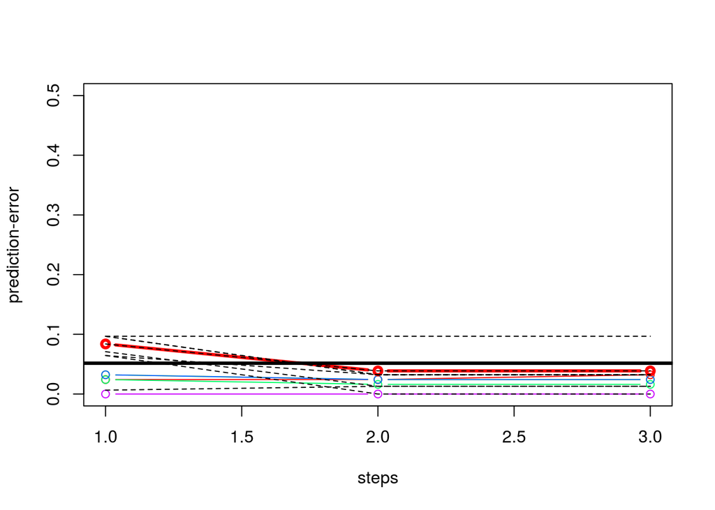

[1] “Prediction error at end is: 0.0838709677419355” [2] “Prediction error at end is: 0.0387096774193548” [3] “Prediction error at end is: 0.0387096774193548”

| k 1 | k 2 | k 3 | k 4 | k 5 |
| --- | --- | --- | --- | --- |
| MinimalCurvature_10m | slope_ws3_10m | maxic_ws5_10m | planc_ws9_hr_hr | longc_ws23_hr_hr |
| slope_DTM_50m_avg_ws11_50m | planc_ws29_hr_hr | planc_ws9_hr_hr | planc_ws29_hr_hr | minic_ws11_10m |
| minic_ws11_hr_hr | planc_ws9_hr_hr | slope_DTM_50m_avg_ws5_50m | minic_ws7_10m | Plan_Curvature_50m |

[1] “OBB error with all predictors of localterrain is 0.032258064516129”

|  | CSR | TG | MeanDecreaseAccuracy | MeanDecreaseGini |
| --- | --- | --- | --- | --- |
| minic_ws7_10m | 0.0040000 | 0.0011772 | 0.0013804 | 0.1469986 |
| slope_DTM_50m_avg_ws11_50m | 0.0146667 | 0.0009084 | 0.0013449 | 0.3411370 |
| slope_DTM_50m_avg_ws5_50m | 0.0143333 | 0.0008334 | 0.0013067 | 0.2492218 |
| slope_DTM_50m_avg_ws9_50m | 0.0081667 | 0.0010153 | 0.0012494 | 0.2892470 |
| minic_ws29_hr_hr | 0.0033333 | 0.0012269 | 0.0012313 | 0.1748671 |
| longc_ws3_10m | 0.0000000 | 0.0007541 | 0.0007317 | 0.0387451 |
| slope_DTM_50m_avg_ws7_50m | 0.0048333 | 0.0006207 | 0.0006953 | 0.2606289 |
| profc_ws11_hr_hr | -0.0006667 | 0.0006622 | 0.0006047 | 0.0901103 |
| minic_ws23_hr_hr | -0.0003333 | 0.0005609 | 0.0005464 | 0.0915164 |
| profc_ws3_10m | 0.0000000 | 0.0005424 | 0.0005325 | 0.0636954 |

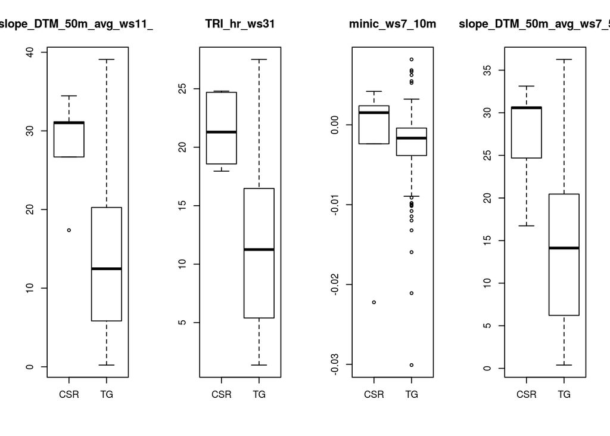

How does this compare to the differences between the units on the geological map?

[1] “OBB error with all predictors of allpreds is 0.0488322717622081”

|  | CSR | TG | MeanDecreaseAccuracy | MeanDecreaseGini |
| --- | --- | --- | --- | --- |
| elev_ws3_10m | 0.0435483 | 0.0126611 | 0.0202923 | 14.910511 |
| elev_ws15_10m | 0.0400116 | 0.0129178 | 0.0195726 | 14.550128 |
| elev_ws11_10m | 0.0408876 | 0.0107461 | 0.0182600 | 13.751900 |
| Channel_Network_Base_Level_hr | 0.0390146 | 0.0100376 | 0.0171419 | 16.128272 |
| elev_ws5_10m | 0.0381962 | 0.0096411 | 0.0167254 | 15.904536 |
| TRI_hr_ws46 | 0.0289235 | 0.0094529 | 0.0141894 | 40.894276 |
| TRI_hr_ws48 | 0.0257130 | 0.0101156 | 0.0140076 | 27.721055 |
| TRI_hr_ws44 | 0.0285458 | 0.0090004 | 0.0137899 | 30.354607 |
| Channel_Network_Base_Level_50m | 0.0374692 | 0.0058943 | 0.0136314 | 13.035631 |
| ChannelNetworkBaseLevel_10m | 0.0354073 | 0.0064874 | 0.0135964 | 7.608163 |

[1] “OBB error with all predictors of roughness is 0.0708410719023614”

|  | CSR | TG | MeanDecreaseAccuracy | MeanDecreaseGini |
| --- | --- | --- | --- | --- |
| TRI_hr_ws49 | 0.0535745 | 0.0307922 | 0.0362702 | 42.42634 |
| TRI_hr_ws50 | 0.0457923 | 0.0283260 | 0.0326484 | 36.47958 |
| TRI_hr_ws48 | 0.0295521 | 0.0317327 | 0.0311952 | 25.30552 |
| TRI_hr_ws47 | 0.0408419 | 0.0274359 | 0.0307307 | 29.27361 |
| TRI_hr_ws45 | 0.0470697 | 0.0238732 | 0.0296388 | 48.70569 |
| TRI_hr_ws46 | 0.0438650 | 0.0248761 | 0.0295756 | 21.56076 |
| TRI_hr_ws42 | 0.0401553 | 0.0229222 | 0.0271635 | 55.94134 |
| TRI_hr_ws44 | 0.0427818 | 0.0210409 | 0.0263186 | 41.55090 |
| TRI_hr_ws43 | 0.0348135 | 0.0209091 | 0.0242969 | 38.52594 |
| TRI_hr_ws37 | 0.0203422 | 0.0242594 | 0.0232262 | 46.28936 |

[1] “OBB error with all predictors of localterrain is 0.0602281772353409”

|  | CSR | TG | MeanDecreaseAccuracy | MeanDecreaseGini |
| --- | --- | --- | --- | --- |
| slope_ws15_10m | 0.0541750 | 0.0191044 | 0.0277009 | 79.19915 |
| slope_DTM_50m_avg_ws7_50m | 0.0662657 | 0.0148018 | 0.0275090 | 51.72822 |
| slope_ws11_10m | 0.0546814 | 0.0171641 | 0.0264896 | 83.48212 |
| slope_DTM_50m_avg_ws9_50m | 0.0589093 | 0.0138737 | 0.0249865 | 57.21299 |
| slope_DTM_50m_avg_ws5_50m | 0.0510423 | 0.0145275 | 0.0235450 | 66.67981 |
| slope_DTM_50m_avg_ws11_50m | 0.0556157 | 0.0110270 | 0.0220689 | 55.14368 |
| slope_DTM_50m_avg_ws3_50m | 0.0410108 | 0.0140289 | 0.0206848 | 81.68360 |
| Slope_50m | 0.0353207 | 0.0119988 | 0.0177476 | 81.31867 |
| slope_ws7_10m | 0.0334535 | 0.0120216 | 0.0172754 | 74.12469 |
| slope_ws23_hr_hr | 0.0222876 | 0.0126691 | 0.0150332 | 49.60894 |

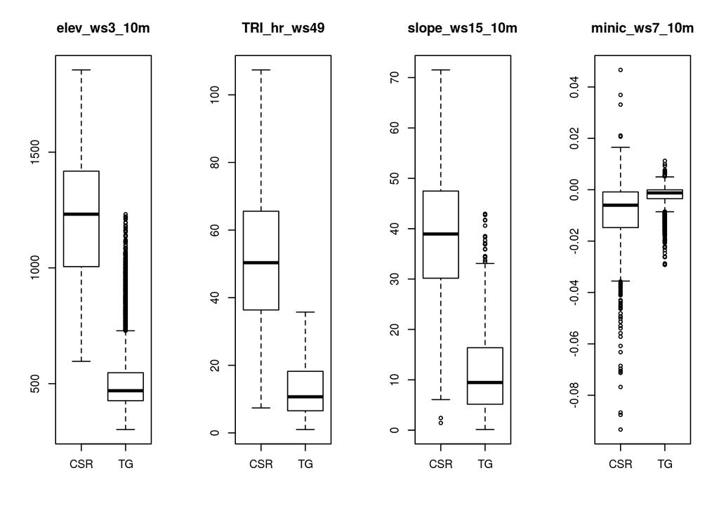

How about slope deposits

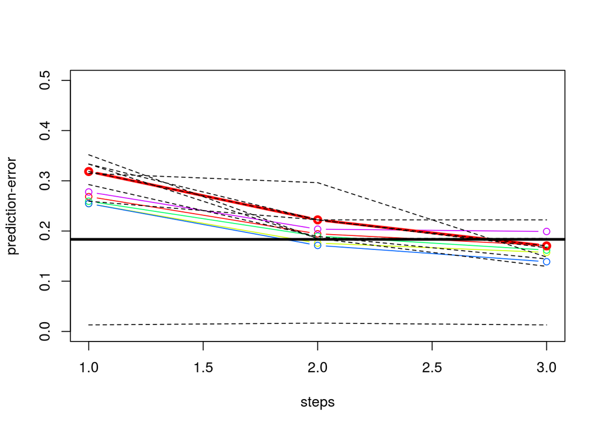

[1] “Prediction error at end is: 0.318518518518519” [2] “Prediction error at end is: 0.222222222222222” [3] “Prediction error at end is: 0.17037037037037”

| k 1 | k 2 | k 3 | k 4 | k 5 |
| --- | --- | --- | --- | --- |
| TRI_hr_ws39 | TRI_hr_ws29 | TRI_hr_ws39 | TRI_hr_ws38 | TRI_hr_ws29 |
| StandardizedHeight_10m | ChannelNetworkBaseLevel_10m | Catchment_slope_50m | Catchment_slope_50m | LS_Factor_50m |
| Slope_Height_50m | Normalized_Height_50m | geom_hr_L50m_fl1_rplipsimpson_UE_hr_60cells_hr | slope_ws23_hr_hr | vectorstrength_hr_ws61_hr |

[1] “OBB error with all predictors of allpreds is 0.185185185185185”

|  | SD | TG | MeanDecreaseAccuracy | MeanDecreaseGini |
| --- | --- | --- | --- | --- |
| Catchment_slope_50m | 0.0119815 | 0.0159629 | 0.0140823 | 2.107014 |
| ChannelNetworkBaseLevel_10m | 0.0112370 | 0.0032301 | 0.0068224 | 1.288718 |
| slope_DTM_50m_avg_ws9_50m | 0.0061384 | 0.0053792 | 0.0057005 | 1.118675 |
| slope_DTM_50m_avg_ws11_50m | 0.0056421 | 0.0059067 | 0.0056839 | 1.045934 |
| Catchment_area_50m | 0.0061600 | 0.0044717 | 0.0052341 | 1.728756 |
| Texture_50m | 0.0031111 | 0.0066187 | 0.0050750 | 1.258798 |
| elev_ws11_10m | 0.0067022 | 0.0026321 | 0.0043873 | 1.038695 |
| TRI_hr_ws36 | 0.0047887 | 0.0040734 | 0.0043277 | 1.216120 |
| Catchment_Area2_50m | 0.0049790 | 0.0035100 | 0.0041487 | 1.281245 |
| TRI_hr_ws42 | 0.0066764 | 0.0022281 | 0.0040748 | 1.288749 |

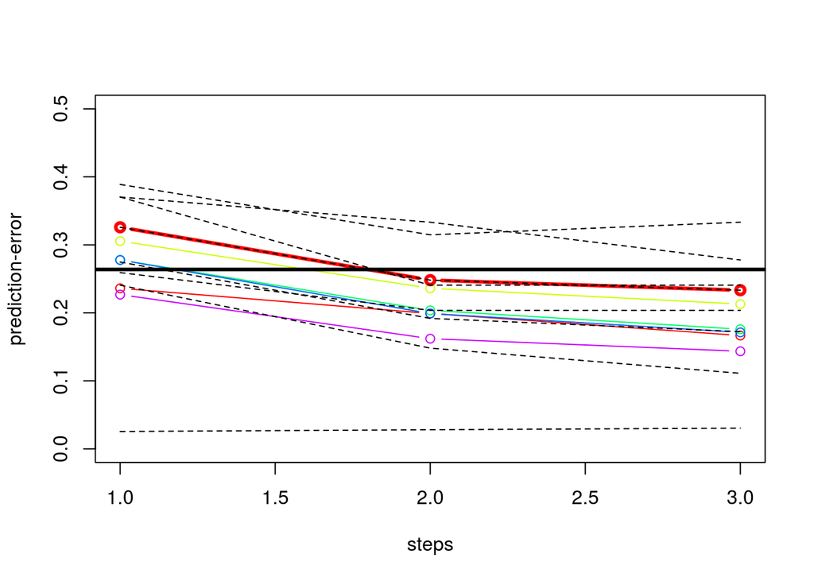

[1] “Prediction error at end is: 0.325925925925926” [2] “Prediction error at end is: 0.248148148148148” [3] “Prediction error at end is: 0.233333333333333”

| k 1 | k 2 | k 3 | k 4 | k 5 |
| --- | --- | --- | --- | --- |
| TRI_hr_ws29 | TRI_hr_ws39 | TRI_hr_ws39 | TRI_hr_ws17 | TRI_hr_ws38 |
| geom_hr_L3_fl1_rplipdominance_UE_hr_60cells_hr | geom_hr_L50m_fl1_rpliprichness_UE_hr_40cells_hr | geom_hr_L50m_fl1_rplipsimpson_UE_hr_60cells_hr | TRI_hr_ws57 | geom_hr_L3_fl1_rplipdominance_UE_hr_60cells_hr |
| terraintexture_hr_ws29_tp25 | TRI_hr_ws55 | geom_hr_L3_fl1_rplipdominance_UE_hr_20cells_hr | fischerk_ws57_hr | geom_hr_L3_fl10_rplipsimpson_UE_hr_60cells_hr |

[1] “OBB error with all predictors of roughness is 0.211111111111111”

|  | SD | TG | MeanDecreaseAccuracy | MeanDecreaseGini |
| --- | --- | --- | --- | --- |
| TRI_hr_ws40 | 0.0146581 | 0.0062402 | 0.0097465 | 2.4464759 |
| Texture_50m | 0.0055539 | 0.0119105 | 0.0090432 | 2.3443495 |
| TRI_hr_ws41 | 0.0110427 | 0.0034632 | 0.0067269 | 2.1434294 |
| TRI_hr_ws39 | 0.0089037 | 0.0042646 | 0.0062652 | 2.0560086 |
| TRI_hr_ws48 | 0.0106503 | 0.0023024 | 0.0059167 | 1.7178603 |
| terraintexture_hr_ws49_tp5 | 0.0112725 | 0.0007567 | 0.0054111 | 0.5390593 |
| TRI_hr_ws38 | 0.0090700 | 0.0026483 | 0.0052528 | 1.7825361 |
| TRI_hr_ws36 | 0.0073169 | 0.0034211 | 0.0051736 | 1.3112803 |
| TRI_hr_ws32 | 0.0053282 | 0.0048520 | 0.0050613 | 1.7683613 |
| TRI_hr_ws30 | 0.0061260 | 0.0039579 | 0.0048030 | 1.3332967 |

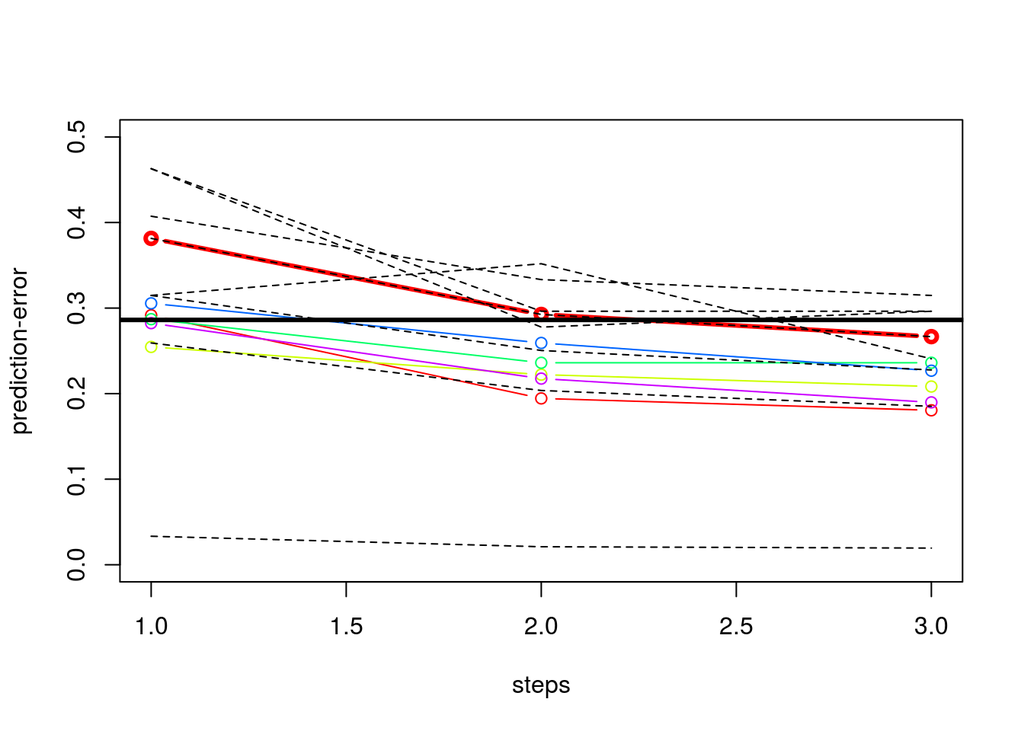

[1] “Prediction error at end is: 0.381481481481481” [2] “Prediction error at end is: 0.292592592592593” [3] “Prediction error at end is: 0.266666666666667”

| k 1 | k 2 | k 3 | k 4 | k 5 |
| --- | --- | --- | --- | --- |
| slope_ws15_10m | slope_ws23_hr_hr | slope_ws23_hr_hr | slope_ws23_hr_hr | slope_ws29_hr_hr |
| Convergence_Index_50m | minic_DTM_50m_avg_ws3_50m | minic_ws11_hr_hr | slope_ws11_10m | slope_DTM_50m_avg_ws5_50m |
| profc_ws15_10m | minic_ws19_hr_hr | Convexity_50m | Minimal_Curvature_50m | profc_ws7_10m |

[1] “OBB error with all predictors of localterrain is 0.203703703703704”

|  | SD | TG | MeanDecreaseAccuracy | MeanDecreaseGini |
| --- | --- | --- | --- | --- |
| slope_DTM_50m_avg_ws11_50m | 0.0223518 | 0.0115926 | 0.0162419 | 4.080252 |
| slope_DTM_50m_avg_ws9_50m | 0.0232822 | 0.0067332 | 0.0140550 | 3.520014 |
| slope_ws15_10m | 0.0189445 | 0.0039442 | 0.0105581 | 3.401466 |
| slope_DTM_50m_avg_ws7_50m | 0.0145268 | 0.0071647 | 0.0100213 | 3.485473 |
| slope_ws11_hr_hr | 0.0148859 | 0.0058968 | 0.0098857 | 3.436043 |
| slope_DTM_50m_avg_ws5_50m | 0.0119092 | 0.0070153 | 0.0090556 | 2.727589 |
| slope_ws29_hr_hr | 0.0102166 | 0.0080091 | 0.0088360 | 2.525616 |
| slope_ws13_hr_hr | 0.0144186 | 0.0032049 | 0.0080515 | 2.627483 |
| slope_ws7_10m | 0.0098131 | 0.0055718 | 0.0073228 | 2.847794 |
| slope_ws19_hr_hr | 0.0104238 | 0.0049351 | 0.0071717 | 2.505970 |

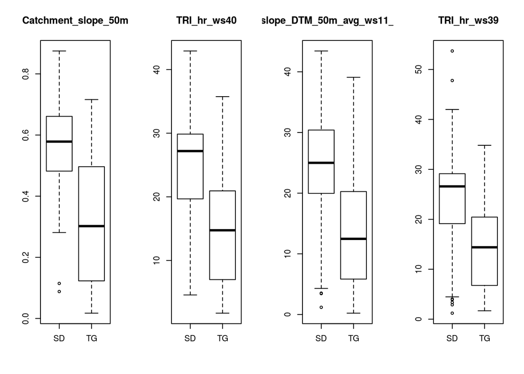

How does this compare to the differences between the units on the geological map?

[1] “OBB error with all predictors of allpreds is 0.0998498498498498”

|  | SD | TG | MeanDecreaseAccuracy | MeanDecreaseGini |
| --- | --- | --- | --- | --- |
| slope_DTM_50m_avg_ws11_50m | 0.0322825 | 0.0135548 | 0.0189379 | 47.54388 |
| slope_DTM_50m_avg_ws7_50m | 0.0249243 | 0.0105899 | 0.0147370 | 45.64590 |
| slope_DTM_50m_avg_ws5_50m | 0.0140768 | 0.0146426 | 0.0145180 | 32.06429 |
| slope_DTM_50m_avg_ws9_50m | 0.0288661 | 0.0081620 | 0.0141666 | 28.06406 |
| TRI_hr_ws48 | 0.0163725 | 0.0122391 | 0.0134422 | 41.33951 |
| TRI_hr_ws50 | 0.0143408 | 0.0109372 | 0.0119708 | 25.63194 |
| TRI_hr_ws49 | 0.0138204 | 0.0104856 | 0.0114558 | 29.15867 |
| TRI_hr_ws43 | 0.0117517 | 0.0110135 | 0.0112489 | 34.27865 |
| TRI_hr_ws44 | 0.0125909 | 0.0099743 | 0.0107397 | 30.34425 |
| slope_DTM_50m_avg_ws3_50m | 0.0119527 | 0.0097970 | 0.0103953 | 27.74723 |

[1] “OBB error with all predictors of roughness is 0.117029257314329”

|  | SD | TG | MeanDecreaseAccuracy | MeanDecreaseGini |
| --- | --- | --- | --- | --- |
| TRI_hr_ws46 | 0.0297924 | 0.0261828 | 0.0272518 | 57.96559 |
| TRI_hr_ws50 | 0.0361412 | 0.0210280 | 0.0253708 | 60.44349 |
| TRI_hr_ws49 | 0.0301113 | 0.0216087 | 0.0240930 | 41.67777 |
| TRI_hr_ws47 | 0.0264921 | 0.0215425 | 0.0229776 | 54.92633 |
| TRI_hr_ws48 | 0.0286211 | 0.0196781 | 0.0223165 | 36.71405 |
| TRI_hr_ws44 | 0.0239595 | 0.0210190 | 0.0218536 | 49.49114 |
| TRI_hr_ws45 | 0.0237937 | 0.0191415 | 0.0205147 | 42.71145 |
| TRI_hr_ws41 | 0.0259670 | 0.0163174 | 0.0191665 | 50.86639 |
| TRI_hr_ws43 | 0.0212678 | 0.0158077 | 0.0174307 | 39.18937 |
| TRI_hr_ws40 | 0.0183545 | 0.0128616 | 0.0144703 | 29.40117 |

[1] “OBB error with all predictors of localterrain is 0.112”

|  | SD | TG | MeanDecreaseAccuracy | MeanDecreaseGini |
| --- | --- | --- | --- | --- |
| slope_DTM_50m_avg_ws9_50m | 0.0595222 | 0.0237005 | 0.0341619 | 114.12449 |
| slope_DTM_50m_avg_ws11_50m | 0.0519662 | 0.0243500 | 0.0323436 | 95.46457 |
| slope_DTM_50m_avg_ws5_50m | 0.0430869 | 0.0267770 | 0.0315142 | 106.19276 |
| slope_DTM_50m_avg_ws7_50m | 0.0490609 | 0.0236092 | 0.0309971 | 88.55476 |
| slope_DTM_50m_avg_ws3_50m | 0.0354340 | 0.0212357 | 0.0253659 | 72.31116 |
| slope_ws15_10m | 0.0284989 | 0.0211238 | 0.0232613 | 54.70641 |
| slope_ws11_10m | 0.0224591 | 0.0202928 | 0.0208651 | 48.67636 |
| Slope_50m | 0.0253437 | 0.0130994 | 0.0166459 | 51.60091 |
| slope_ws7_10m | 0.0178693 | 0.0136204 | 0.0148521 | 50.53821 |
| slope_ws29_hr_hr | 0.0113659 | 0.0139774 | 0.0131859 | 40.00706 |

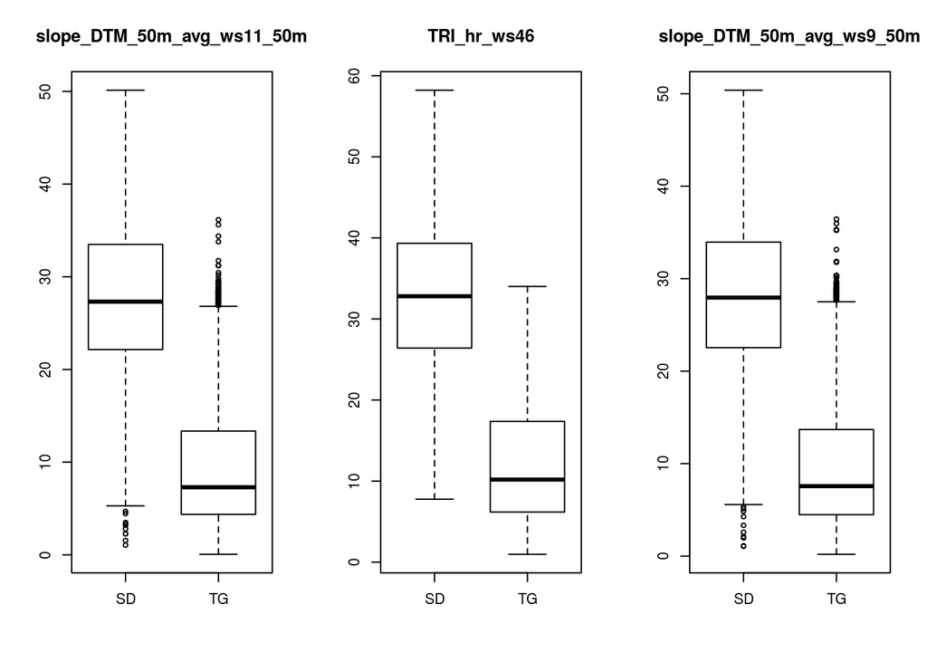

How about debris cones

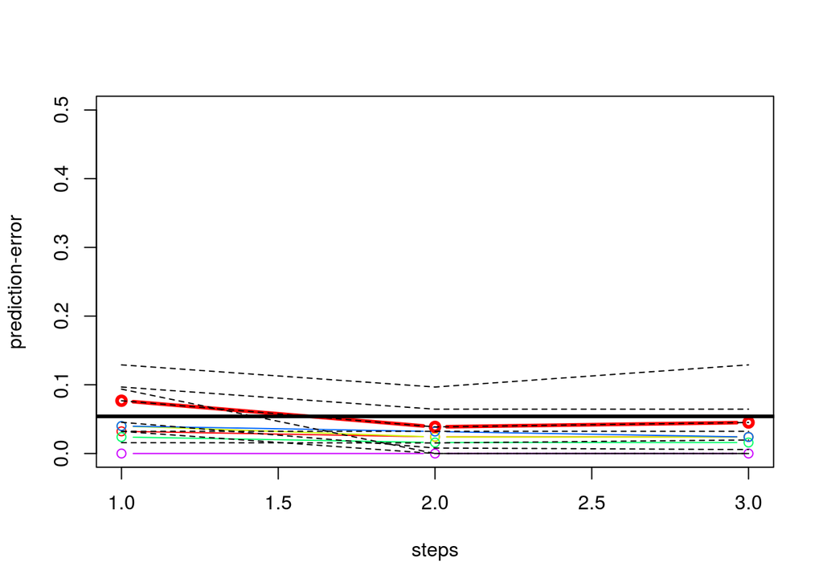

[1] “Prediction error at end is: 0.0768145161290323” [2] “Prediction error at end is: 0.0387096774193548” [3] “Prediction error at end is: 0.0451612903225806”

| k 1 | k 2 | k 3 | k 4 | k 5 |
| --- | --- | --- | --- | --- |
| geom_hr_L3_fl10_rplipmps_UE_hr_20cells_hr | profc_DTM_50m_avg_ws7_50m | VerticalDistancetoChannelNetwork_10m | longc_DTM_50m_avg_ws11_50m | LongitudinalCurvature_10m |
| geom_hr_L3_fl1_rpliprichness_UE_hr_60cells_hr | geom_hr_L3_fl1_rpliprichness_UE_hr_20cells_hr | TRI_hr_ws3 | profc_DTM_50m_avg_ws7_50m | slope_DTM_50m_avg_ws3_50m |
| slope_ws7_10m | geom_hr_L50m_fl1_rpliprichness_UE_hr_40cells_hr | profc_DTM_50m_avg_ws9_50m | planc_DTM_50m_avg_ws9_50m | planc_ws7_hr_hr |

[1] “OBB error with all predictors of allpreds is 0.0384615384615385”

|  | DC | TG | MeanDecreaseAccuracy | MeanDecreaseGini |
| --- | --- | --- | --- | --- |
| elev_ws15_10m | 0.0250000 | 0.0006939 | 0.0013762 | 0.4033415 |
| elev_ws5_10m | 0.0163333 | 0.0006581 | 0.0011971 | 0.3706070 |
| Catchment_Area2_50m | 0.0093333 | 0.0008255 | 0.0011465 | 0.1178742 |
| elev_ws11_10m | 0.0180000 | 0.0005451 | 0.0010828 | 0.4224518 |
| elev_ws3_10m | 0.0143333 | 0.0005570 | 0.0010687 | 0.5219282 |
| Standardized_Height_50m | 0.0128333 | 0.0005647 | 0.0009960 | 0.2813810 |
| Topographic_Wetness_Index_50m | 0.0078333 | 0.0006868 | 0.0009057 | 0.0709861 |
| vectorruggedness_hr_ws57 | 0.0036667 | 0.0007059 | 0.0008155 | 0.1249406 |
| fischerk_ws13_hr | 0.0037333 | 0.0006391 | 0.0007539 | 0.0889141 |
| geom_hr_L50m_fl10_rplipshannon_UE_hr_20cells_hr | 0.0000000 | 0.0006248 | 0.0006051 | 0.0473333 |

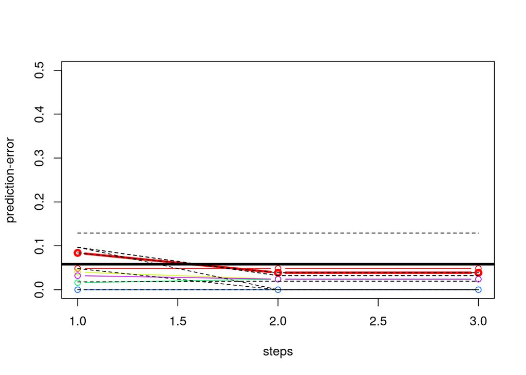

[1] “Prediction error at end is: 0.0838709677419355” [2] “Prediction error at end is: 0.0387096774193548” [3] “Prediction error at end is: 0.0387096774193548”

| k 1 | k 2 | k 3 | k 4 | k 5 |
| --- | --- | --- | --- | --- |
| geom_hr_L3_fl10_rpliprichness_UE_hr_10cells_hr | geom_hr_L3_fl10_rplippatchdensity_UE_hr_40cells_hr | TRI_hr_ws3 | geom_hr_L50m_fl1_rplipedgedensity_UE_hr_20cells_hr | geom_hr_L3_fl10_rplipmps_UE_hr_20cells_hr |
| geom_hr_L3_fl10_rpliprichness_UE_hr_20cells_hr | vectorruggedness_hr_ws13 | geom_hr_L50m_fl10_rplipmps_UE_hr_20cells_hr | geom_hr_L50m_fl1_rplipshape_UE_hr_20cells_hr | fischerk_ws13_hr |
| geom_hr_L3_fl10_rpliprichness_UE_hr_40cells_hr | geom_hr_L3_fl10_rplipshannon_UE_hr_60cells_hr | geom_hr_L3_fl10_rplippatchdensity_UE_hr_20cells_hr | geom_hr_L3_fl10_rplipdominance_UE_hr_5cells_hr | vectorstrength_hr_ws13_hr |

[1] “OBB error with all predictors of roughness is 0.0384615384615385”

|  | DC | TG | MeanDecreaseAccuracy | MeanDecreaseGini |
| --- | --- | --- | --- | --- |
| Texture_50m | 0.0148333 | 0.0013106 | 0.0017844 | 0.5393309 |
| vectorruggedness_hr_ws57 | 0.0056667 | 0.0012421 | 0.0014100 | 0.1898335 |
| fischerk_ws13_hr | 0.0051667 | 0.0011332 | 0.0012618 | 0.1625853 |
| vectorruggedness_hr_ws21 | 0.0010000 | 0.0011663 | 0.0011764 | 0.0858375 |
| geom_hr_L3_fl10_rplipedgedensity_UE_hr_60cells_hr | 0.0000000 | 0.0011440 | 0.0011056 | 0.0986167 |
| vectorruggedness_hr_ws55 | 0.0006667 | 0.0010899 | 0.0010932 | 0.1557399 |
| dtm_hr_TEXTURE_r20 | 0.0015000 | 0.0010143 | 0.0010422 | 0.0775507 |
| vectorruggedness_hr_ws43 | -0.0010000 | 0.0010381 | 0.0009509 | 0.0574573 |
| geom_hr_L50m_fl10_rplipshape_UE_hr_20cells_hr | 0.0006667 | 0.0009175 | 0.0009212 | 0.0681941 |
| vectorruggedness_hr_ws49 | 0.0005000 | 0.0009222 | 0.0009174 | 0.0788216 |

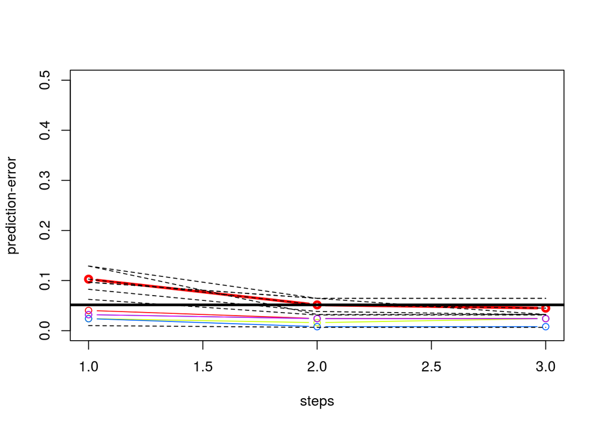

[1] “Prediction error at end is: 0.102822580645161” [2] “Prediction error at end is: 0.0514112903225806” [3] “Prediction error at end is: 0.0449596774193548”

| k 1 | k 2 | k 3 | k 4 | k 5 |
| --- | --- | --- | --- | --- |
| Convergence_Index_50m | profc_DTM_50m_avg_ws9_50m | crosc_ws7_hr_hr | LongitudinalCurvature_10m | minic_ws11_10m |
| profc_DTM_50m_avg_ws5_50m | maxic_ws13_hr_hr | LongitudinalCurvature_10m | slope_DTM_50m_avg_ws3_50m | planc_ws15_hr_hr |
| longc_ws11_10m | profc_ws15_10m | Longitudinal_Curvature_hr | maxic_DTM_50m_avg_ws9_50m | profc_ws9_hr_hr |

[1] “OBB error with all predictors of localterrain is 0.0384615384615385”

|  | DC | TG | MeanDecreaseAccuracy | MeanDecreaseGini |
| --- | --- | --- | --- | --- |
| TotalCurvature_10m | 0.0116667 | 0.0030980 | 0.0033831 | 0.2016333 |
| maxic_ws3_10m | 0.0050000 | 0.0024295 | 0.0024833 | 0.0829568 |
| minic_ws5_10m | 0.0046667 | 0.0023246 | 0.0023861 | 0.1137377 |
| maxic_ws5_10m | -0.0048333 | 0.0026520 | 0.0023639 | 0.0982658 |
| maxic_ws19_hr_hr | 0.0000000 | 0.0021017 | 0.0020213 | 0.0423863 |
| Slope_hr | 0.0026667 | 0.0020064 | 0.0019453 | 0.0782496 |
| ProfileCurvature_10m | -0.0056667 | 0.0021541 | 0.0019405 | 0.0722500 |
| Total_Curvature_50m | 0.0118333 | 0.0015132 | 0.0018551 | 0.3587477 |
| GeneralCurvature_10m | -0.0050000 | 0.0019869 | 0.0018430 | 0.1239626 |
| slope_ws23_hr_hr | -0.0025000 | 0.0020067 | 0.0018217 | 0.0377365 |

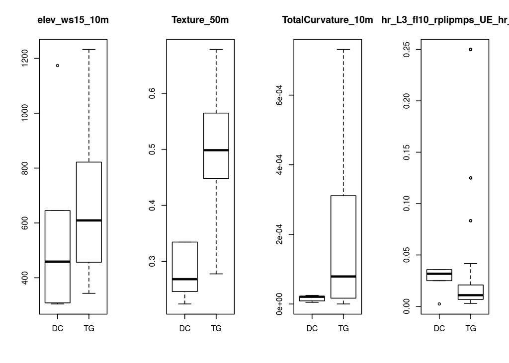

How does this compare to the differences between the units on the geological map?

[1] “OBB error with all predictors of allpreds is 0.0253122945430638”

|  | CBD | TG | MeanDecreaseAccuracy | MeanDecreaseGini |
| --- | --- | --- | --- | --- |
| slope_DTM_50m_avg_ws7_50m | 0.0486332 | 0.0063678 | 0.0091648 | 15.086012 |
| slope_DTM_50m_avg_ws5_50m | 0.0274136 | 0.0058430 | 0.0072677 | 10.138202 |
| slope_DTM_50m_avg_ws11_50m | 0.0440646 | 0.0027853 | 0.0055438 | 13.780407 |
| slope_DTM_50m_avg_ws9_50m | 0.0345768 | 0.0028121 | 0.0049476 | 11.112497 |
| TRI_hr_ws46 | 0.0154676 | 0.0035258 | 0.0043256 | 7.869682 |
| TRI_hr_ws48 | 0.0128188 | 0.0035239 | 0.0041390 | 5.443082 |
| TRI_hr_ws49 | 0.0128733 | 0.0028057 | 0.0034748 | 6.883938 |
| TRI_hr_ws50 | 0.0132452 | 0.0027477 | 0.0034176 | 6.198394 |
| slope_DTM_50m_avg_ws3_50m | 0.0108828 | 0.0028411 | 0.0033685 | 5.940061 |
| TRI_hr_ws44 | 0.0104004 | 0.0028249 | 0.0033222 | 6.608064 |

[1] “OBB error with all predictors of roughness is 0.040092014459415”

|  | CBD | TG | MeanDecreaseAccuracy | MeanDecreaseGini |
| --- | --- | --- | --- | --- |
| TRI_hr_ws49 | 0.0398909 | 0.0104102 | 0.0123808 | 9.968941 |
| TRI_hr_ws46 | 0.0357361 | 0.0092539 | 0.0110407 | 10.609426 |
| TRI_hr_ws50 | 0.0424148 | 0.0079395 | 0.0102443 | 10.648976 |
| TRI_hr_ws42 | 0.0179580 | 0.0095216 | 0.0101347 | 6.605540 |
| TRI_hr_ws44 | 0.0252318 | 0.0087850 | 0.0098863 | 8.329179 |
| TRI_hr_ws48 | 0.0218077 | 0.0089252 | 0.0098321 | 6.529749 |
| TRI_hr_ws47 | 0.0303109 | 0.0080953 | 0.0096291 | 9.745109 |
| TRI_hr_ws45 | 0.0225624 | 0.0073071 | 0.0083652 | 9.146801 |
| TRI_hr_ws43 | 0.0258594 | 0.0069993 | 0.0082755 | 9.490862 |
| TRI_hr_ws39 | 0.0121050 | 0.0075770 | 0.0078601 | 5.868401 |

[1] “OBB error with all predictors of localterrain is 0.0325336838646073”

|  | CBD | TG | MeanDecreaseAccuracy | MeanDecreaseGini |
| --- | --- | --- | --- | --- |
| slope_DTM_50m_avg_ws7_50m | 0.0894804 | 0.0079781 | 0.0134425 | 32.689986 |
| slope_DTM_50m_avg_ws9_50m | 0.1003256 | 0.0054035 | 0.0117681 | 31.794073 |
| slope_DTM_50m_avg_ws11_50m | 0.0856906 | 0.0041336 | 0.0096060 | 26.749726 |
| slope_DTM_50m_avg_ws5_50m | 0.0525790 | 0.0060261 | 0.0091460 | 19.658904 |
| slope_DTM_50m_avg_ws3_50m | 0.0312630 | 0.0039160 | 0.0057676 | 13.042726 |
| slope_ws11_10m | 0.0180729 | 0.0044192 | 0.0052883 | 9.385871 |
| slope_ws15_10m | 0.0223037 | 0.0038483 | 0.0050988 | 12.729373 |
| Slope_50m | 0.0213710 | 0.0036426 | 0.0048330 | 12.217377 |
| slope_ws23_hr_hr | 0.0047055 | 0.0044250 | 0.0044505 | 4.730090 |
| slope_ws29_hr_hr | 0.0100634 | 0.0039100 | 0.0043201 | 7.491630 |

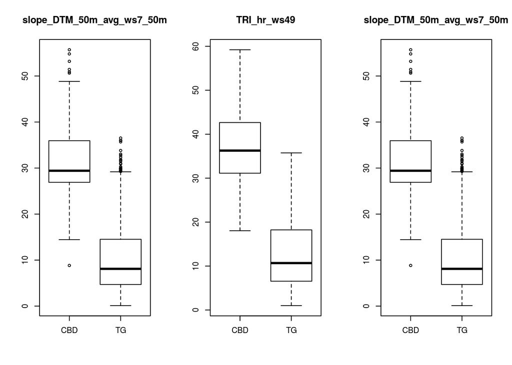

How about coarse blocky debris

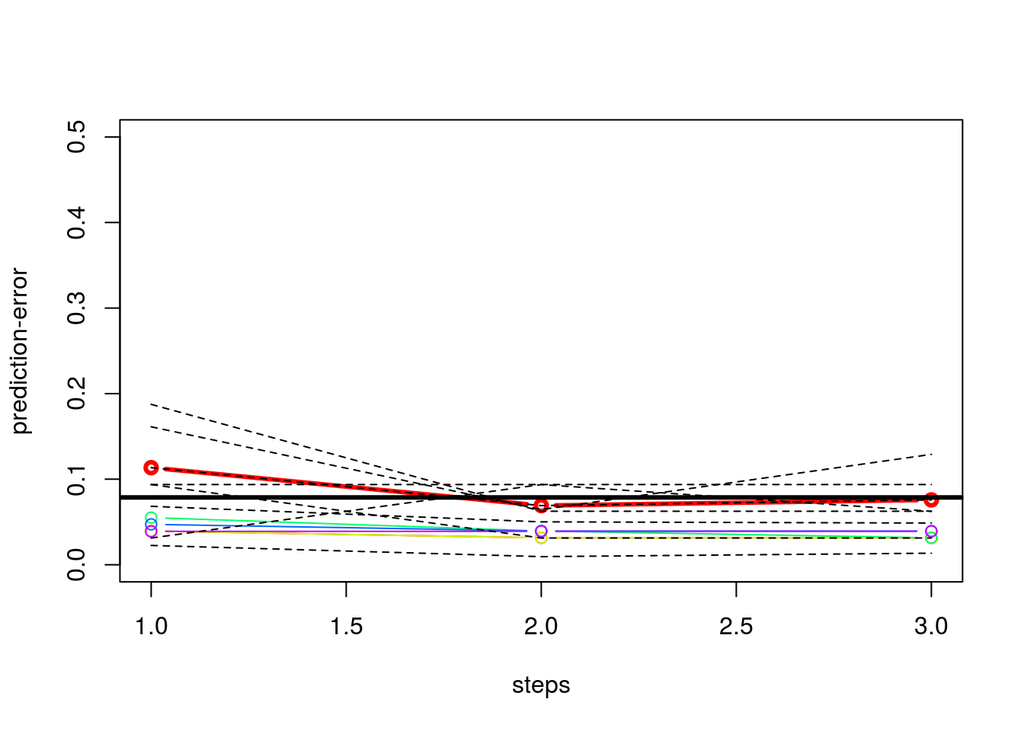

[1] “Prediction error at end is: 0.113508064516129” [2] “Prediction error at end is: 0.0691532258064516” [3] “Prediction error at end is: 0.0758064516129032”

| k 1 | k 2 | k 3 | k 4 | k 5 |
| --- | --- | --- | --- | --- |
| geom_hr_L50m_fl10_rplippatchnum_UE_hr_60cells_hr | minic_ws23_hr_hr | slope_DTM_50m_avg_ws3_50m | profc_ws11_hr_hr | crosc_ws15_10m |
| longc_ws19_hr_hr | geom_hr_L3_fl10_rplipmps_UE_hr_10cells_hr | minic_DTM_50m_avg_ws11_50m | Texture_10m | geom_hr_L50m_fl10_rplipshannon_UE_hr_5cells_hr |
| geom_hr_L50m_fl10_rplipmps_UE_hr_60cells_hr | Longitudinal_Curvature_hr | vectorruggedness_hr_ws13 | terraintexture_hr_ws25_tp25 | profc_ws5_hr_hr |

[1] “OBB error with all predictors of allpreds is 0.0691823899371069”

|  | CBD | TG | MeanDecreaseAccuracy | MeanDecreaseGini |
| --- | --- | --- | --- | --- |
| slope_DTM_50m_avg_ws11_50m | 0.0135000 | 0.0013335 | 0.0019944 | 0.3036573 |
| elev_ws11_10m | 0.0060000 | 0.0006480 | 0.0008961 | 0.1763652 |
| longc_ws5_hr_hr | 0.0055000 | 0.0006395 | 0.0008756 | 0.2086410 |
| Channel_Network_Base_Level_hr | 0.0003333 | 0.0008897 | 0.0008421 | 0.0805331 |
| slope_DTM_50m_avg_ws9_50m | 0.0025667 | 0.0006975 | 0.0008356 | 0.1706524 |
| profc_ws13_hr_hr | -0.0005000 | 0.0008561 | 0.0007814 | 0.0397187 |
| Profile_Curvature_hr | 0.0035667 | 0.0005964 | 0.0007736 | 0.1673060 |
| elev_ws3_10m | 0.0023667 | 0.0005725 | 0.0007133 | 0.1058989 |
| Catchment_slope_50m | 0.0014000 | 0.0006202 | 0.0006951 | 0.1634688 |
| MaximalCurvature_10m | 0.0063333 | 0.0004543 | 0.0006703 | 0.2306124 |

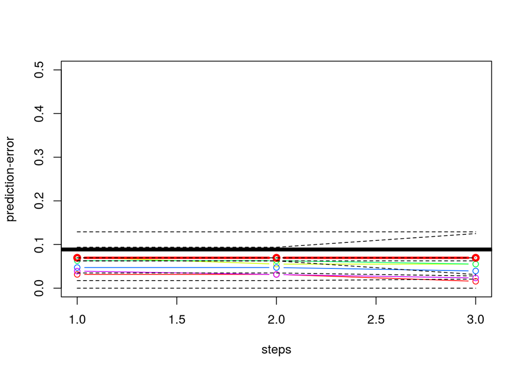

[1] “Prediction error at end is: 0.0695564516129032” [2] “Prediction error at end is: 0.0695564516129032” [3] “Prediction error at end is: 0.0695564516129032”

| k 1 | k 2 | k 3 | k 4 | k 5 |
| --- | --- | --- | --- | --- |
| geom_hr_L50m_fl10_rplipmps_UE_hr_60cells_hr | geom_hr_L3_fl10_rplipedgedensity_UE_hr_5cells_hr | geom_hr_L3_fl10_rplippatchdensity_UE_hr_20cells_hr | geom_hr_L3_fl10_rplippatchdensity_UE_hr_20cells_hr | geom_hr_L3_fl10_rplipmps_UE_hr_10cells_hr |
| geom_hr_L50m_fl10_rplippatchdensity_UE_hr_60cells_hr | geom_hr_L3_fl1_rpliprichness_UE_hr_20cells_hr | geom_hr_L3_fl10_rplippatchnum_UE_hr_20cells_hr | geom_hr_L3_fl10_rplippatchnum_UE_hr_20cells_hr | geom_hr_L3_fl1_rplipdominance_UE_hr_20cells_hr |
| geom_hr_L3_fl1_rpliprichness_UE_hr_40cells_hr | TRI_hr_ws1 | geom_hr_L50m_fl1_rplipsimpson_UE_hr_10cells_hr | dtm_hr_TEXTURE_r5 | geom_hr_L3_fl10_rplipsimpson_UE_hr_60cells_hr |

[1] “OBB error with all predictors of roughness is 0.0628930817610063”

|  | CBD | TG | MeanDecreaseAccuracy | MeanDecreaseGini |
| --- | --- | --- | --- | --- |
| TRI_hr_ws44 | 0.0090000 | 0.0016964 | 0.0021917 | 0.2544479 |
| TRI_hr_ws48 | 0.0044333 | 0.0017581 | 0.0021061 | 0.4302100 |
| TRI_hr_ws45 | 0.0106667 | 0.0015039 | 0.0019539 | 0.3440365 |
| TRI_hr_ws46 | 0.0082333 | 0.0012756 | 0.0016220 | 0.2187885 |
| TRI_hr_ws47 | 0.0086333 | 0.0010984 | 0.0016168 | 0.3855540 |
| TRI_hr_ws38 | 0.0049667 | 0.0013055 | 0.0015479 | 0.2248294 |
| TRI_hr_ws43 | 0.0067000 | 0.0012747 | 0.0015378 | 0.3370713 |
| TRI_hr_ws49 | 0.0051333 | 0.0012676 | 0.0015103 | 0.2840693 |
| dtm_hr_TEXTURE_r30 | 0.0021667 | 0.0011902 | 0.0012020 | 0.1011143 |
| TRI_hr_ws39 | 0.0049667 | 0.0009347 | 0.0011902 | 0.2229911 |

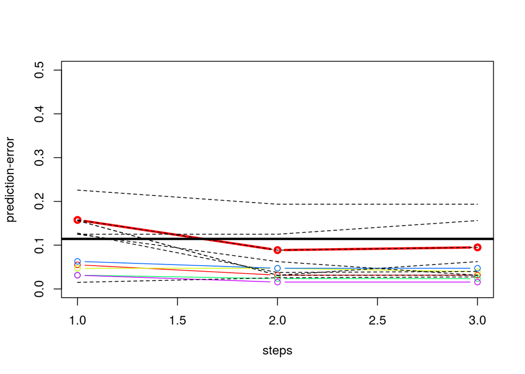

[1] “Prediction error at end is: 0.157661290322581” [2] “Prediction error at end is: 0.0887096774193548” [3] “Prediction error at end is: 0.0949596774193548”

| k 1 | k 2 | k 3 | k 4 | k 5 |
| --- | --- | --- | --- | --- |
| MinimalCurvature_10m | slope_ws13_hr_hr | longc_DTM_50m_avg_ws9_50m | longc_DTM_50m_avg_ws9_50m | MaximalCurvature_10m |
| minic_ws9_hr_hr | longc_ws29_hr_hr | profc_ws5_hr_hr | slope_ws5_hr_hr | maxic_ws11_10m |
| TotalCurvature_10m | slope_ws11_10m | Minimal_Curvature_hr | slope_DTM_50m_avg_ws11_50m | GeneralCurvature_10m |

[1] “OBB error with all predictors of localterrain is 0.0691823899371069”

|  | CBD | TG | MeanDecreaseAccuracy | MeanDecreaseGini |
| --- | --- | --- | --- | --- |
| slope_DTM_50m_avg_ws11_50m | 0.0212667 | 0.0022584 | 0.0031873 | 0.7411853 |
| profc_ws13_hr_hr | 0.0036667 | 0.0018266 | 0.0019168 | 0.0741824 |
| MaximalCurvature_10m | 0.0077333 | 0.0015019 | 0.0018714 | 0.4536263 |
| longc_ws13_hr_hr | 0.0037333 | 0.0017173 | 0.0018173 | 0.0946769 |
| ProfileCurvature_10m | -0.0006000 | 0.0017057 | 0.0016192 | 0.1038724 |
| longc_ws11_10m | 0.0068000 | 0.0010906 | 0.0013618 | 0.3676343 |
| Longitudinal_Curvature_hr | -0.0021667 | 0.0014038 | 0.0013007 | 0.1719618 |
| longc_DTM_50m_avg_ws11_50m | 0.0071333 | 0.0008939 | 0.0012115 | 0.3741762 |
| profc_ws11_hr_hr | -0.0009000 | 0.0011747 | 0.0011560 | 0.0979050 |
| profc_ws9_hr_hr | -0.0006667 | 0.0011301 | 0.0010428 | 0.1638502 |

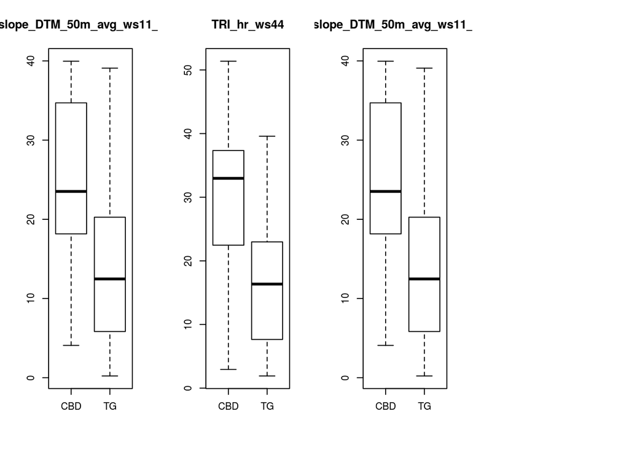

How does this compare to the differences between the units on the geological map?

[1] “OBB error with all predictors of allpreds is 0.0266272189349112”

|  | CBD | TG | MeanDecreaseAccuracy | MeanDecreaseGini |
| --- | --- | --- | --- | --- |
| slope_DTM_50m_avg_ws7_50m | 0.0416690 | 0.0058307 | 0.0082617 | 11.975806 |
| slope_DTM_50m_avg_ws5_50m | 0.0284593 | 0.0055762 | 0.0070805 | 11.210865 |
| slope_DTM_50m_avg_ws9_50m | 0.0410196 | 0.0036228 | 0.0061548 | 12.357436 |
| slope_DTM_50m_avg_ws11_50m | 0.0390213 | 0.0023939 | 0.0048585 | 12.867064 |
| TRI_hr_ws50 | 0.0188854 | 0.0029231 | 0.0039815 | 8.030484 |
| TRI_hr_ws48 | 0.0119541 | 0.0033372 | 0.0039190 | 5.848991 |
| TRI_hr_ws49 | 0.0114726 | 0.0029894 | 0.0035492 | 3.994362 |
| TRI_hr_ws45 | 0.0155968 | 0.0025937 | 0.0034980 | 7.027573 |
| TRI_hr_ws47 | 0.0105779 | 0.0029198 | 0.0034183 | 4.770062 |
| slope_DTM_50m_avg_ws3_50m | 0.0104087 | 0.0028738 | 0.0033685 | 5.485550 |

[1] “OBB error with all predictors of roughness is 0.0384488991127177”

|  | CBD | TG | MeanDecreaseAccuracy | MeanDecreaseGini |
| --- | --- | --- | --- | --- |
| TRI_hr_ws48 | 0.0444367 | 0.0100689 | 0.0123578 | 13.145423 |
| TRI_hr_ws49 | 0.0297354 | 0.0098592 | 0.0111842 | 8.417950 |
| TRI_hr_ws50 | 0.0357548 | 0.0093130 | 0.0110757 | 10.187386 |
| TRI_hr_ws47 | 0.0372946 | 0.0079389 | 0.0099208 | 11.208908 |
| TRI_hr_ws46 | 0.0331277 | 0.0081781 | 0.0098551 | 10.254783 |
| TRI_hr_ws44 | 0.0256055 | 0.0078621 | 0.0090860 | 8.073319 |
| TRI_hr_ws45 | 0.0271099 | 0.0078528 | 0.0090573 | 9.061292 |
| TRI_hr_ws41 | 0.0145521 | 0.0078067 | 0.0082548 | 6.080424 |
| TRI_hr_ws42 | 0.0180205 | 0.0064645 | 0.0072239 | 7.030391 |
| TRI_hr_ws36 | 0.0138888 | 0.0064609 | 0.0069431 | 6.202708 |

[1] “OBB error with all predictors of localterrain is 0.0345054222806441”

|  | CBD | TG | MeanDecreaseAccuracy | MeanDecreaseGini |
| --- | --- | --- | --- | --- |
| slope_DTM_50m_avg_ws7_50m | 0.0885764 | 0.0079064 | 0.0133433 | 29.182973 |
| slope_DTM_50m_avg_ws9_50m | 0.0955315 | 0.0070286 | 0.0129110 | 28.343211 |
| slope_DTM_50m_avg_ws5_50m | 0.0509812 | 0.0073359 | 0.0103227 | 20.170808 |
| slope_DTM_50m_avg_ws11_50m | 0.0838803 | 0.0040994 | 0.0094649 | 24.468311 |
| Slope_50m | 0.0200714 | 0.0050793 | 0.0060717 | 10.839392 |
| slope_ws7_10m | 0.0139202 | 0.0050651 | 0.0056366 | 8.690545 |
| slope_ws15_10m | 0.0251912 | 0.0042087 | 0.0056346 | 11.756871 |
| slope_DTM_50m_avg_ws3_50m | 0.0234107 | 0.0042555 | 0.0055343 | 12.224804 |
| slope_ws11_10m | 0.0193113 | 0.0037541 | 0.0048221 | 13.618779 |
| slope_ws19_hr_hr | 0.0028913 | 0.0039310 | 0.0038703 | 5.004622 |

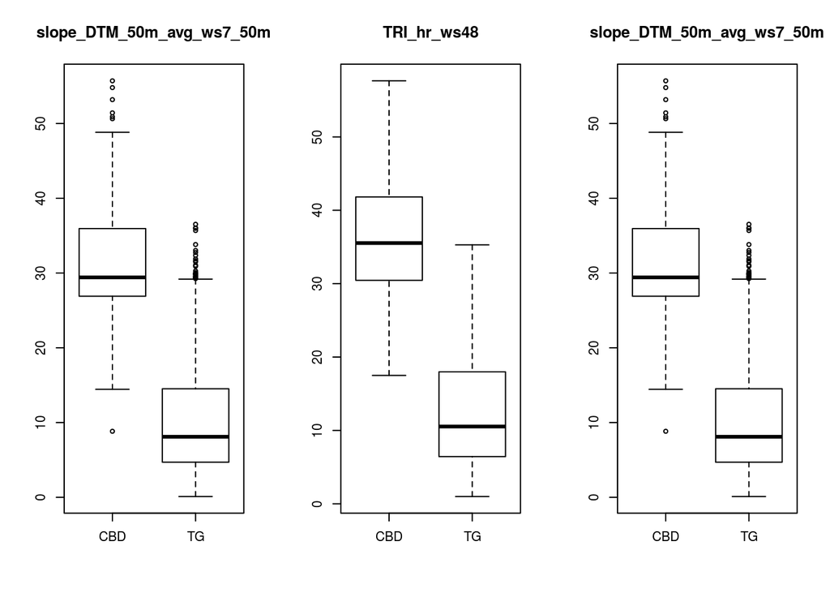

How about glaciolacustrine deposits

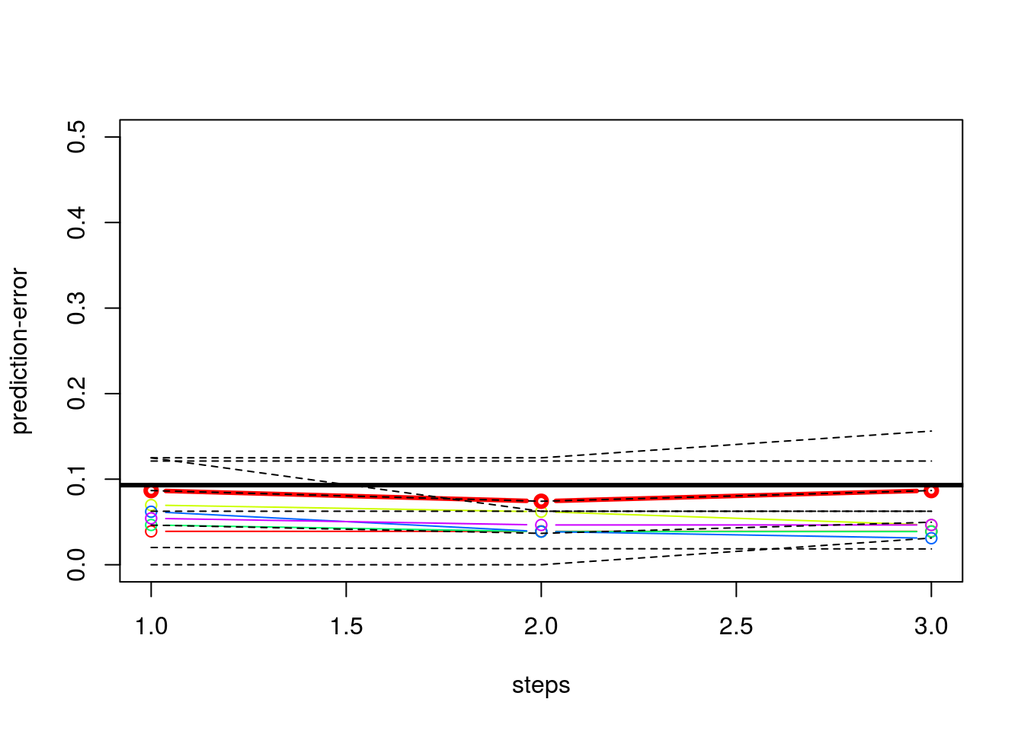

[1] “Prediction error at end is: 0.0867424242424242” [2] “Prediction error at end is: 0.0742424242424242” [3] “Prediction error at end is: 0.0867424242424242”

| k 1 | k 2 | k 3 | k 4 | k 5 |
| --- | --- | --- | --- | --- |
| geom_hr_L50m_fl1_rpliprichness_UE_hr_40cells_hr | geom_hr_L50m_fl1_rpliprichness_UE_hr_40cells_hr | geom_hr_L50m_fl10_rpliprichness_UE_hr_20cells_hr | Channel_Network_Base_Level_50m | geom_hr_L50m_fl1_rpliprichness_UE_hr_40cells_hr |
| geom_hr_L3_fl1_rplipmps_UE_hr_20cells_hr | elev_ws3_10m | longc_ws3_hr_hr | elev_ws5_10m | planc_DTM_50m_avg_ws11_50m |
| geom_hr_L3_fl1_rplipedgedensity_UE_hr_10cells_hr | VerticalDistancetoChannelNetwork_10m | longc_ws11_10m | Maximal_Curvature_50m | profc_DTM_50m_avg_ws11_50m |

[1] “OBB error with all predictors of allpreds is 0.0683229813664596”

|  | GLD | TG | MeanDecreaseAccuracy | MeanDecreaseGini |
| --- | --- | --- | --- | --- |
| Slope_Height_hr | 0.0035667 | 0.0010435 | 0.0012130 | 0.1953534 |
| elev_ws3_10m | 0.0087667 | 0.0007331 | 0.0011933 | 0.4268410 |
| elev_ws15_10m | 0.0056048 | 0.0005994 | 0.0009948 | 0.4261819 |
| Maximal_Curvature_50m | 0.0055690 | 0.0006655 | 0.0009887 | 0.2744315 |
| elev_ws11_10m | 0.0094524 | 0.0003819 | 0.0009309 | 0.4260193 |
| Channel_Network_Base_Level_hr | 0.0119143 | 0.0002611 | 0.0008884 | 0.4801128 |
| elev_ws5_10m | 0.0066881 | 0.0004257 | 0.0008624 | 0.3884974 |
| geom_hr_L3_fl1_rplipdominance_UE_hr_60cells_hr | 0.0045548 | 0.0004908 | 0.0007955 | 0.3198491 |
| profc_DTM_50m_avg_ws11_50m | 0.0035190 | 0.0006342 | 0.0007830 | 0.1101508 |
| LS_Factor_50m | 0.0050000 | 0.0004701 | 0.0007126 | 0.1743936 |

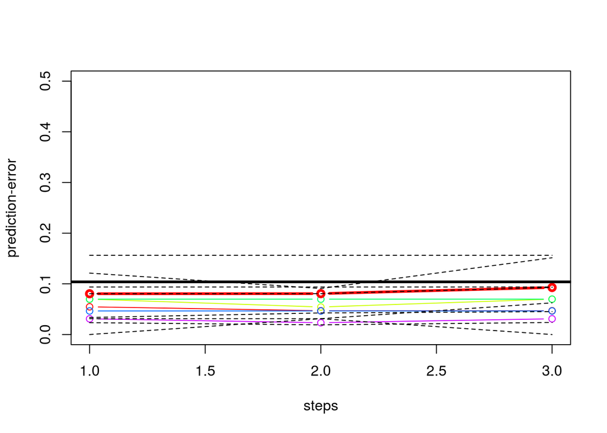

[1] “Prediction error at end is: 0.0804924242424242” [2] “Prediction error at end is: 0.0806818181818182” [3] “Prediction error at end is: 0.0928030303030303”

| k 1 | k 2 | k 3 | k 4 | k 5 |
| --- | --- | --- | --- | --- |
| geom_hr_L3_fl10_rplipedgedensity_UE_hr_10cells_hr | geom_hr_L50m_fl10_rpliprichness_UE_hr_20cells_hr | geom_hr_L50m_fl1_rpliprichness_UE_hr_40cells_hr | geom_hr_L50m_fl1_rplipedgedensity_UE_hr_10cells_hr | geom_hr_L50m_fl1_rpliprichness_UE_hr_40cells_hr |
| fischerk_ws55_hr | geom_hr_L50m_fl10_rplipdominance_UE_hr_40cells_hr | geom_hr_L50m_fl10_rplipdominance_UE_hr_60cells_hr | geom_hr_L50m_fl1_rplipshape_UE_hr_10cells_hr | vectorstrength_hr_ws9_hr |
| vectorstrength_hr_ws55_hr | geom_hr_L50m_fl1_rplipmps_UE_hr_10cells_hr | terraintexture_hr_ws29_tp5 | geom_hr_L3_fl10_rplipmps_UE_hr_10cells_hr | TRI_hr_ws38 |

[1] “OBB error with all predictors of roughness is 0.0683229813664596”

|  | GLD | TG | MeanDecreaseAccuracy | MeanDecreaseGini |
| --- | --- | --- | --- | --- |
| vectorstrength_hr_ws49_hr | -0.0013333 | 0.0021152 | 0.0018824 | 0.0601250 |
| TRI_hr_ws43 | -0.0010000 | 0.0013872 | 0.0012585 | 0.0253533 |
| vectorstrength_hr_ws59_hr | -0.0019000 | 0.0014075 | 0.0012222 | 0.0847557 |
| fischerk_ws41_hr | -0.0009333 | 0.0012725 | 0.0011069 | 0.0708471 |
| vectorstrength_hr_ws57_hr | -0.0013333 | 0.0012388 | 0.0010774 | 0.0652703 |
| TRI_hr_ws41 | -0.0015000 | 0.0012787 | 0.0010659 | 0.0940951 |
| vectorstrength_hr_ws51_hr | -0.0010000 | 0.0011399 | 0.0010344 | 0.0389768 |
| terraintexture_hr_ws45_tp25 | -0.0003333 | 0.0011535 | 0.0010236 | 0.0391154 |
| fischerk_ws39_hr | 0.0000000 | 0.0010542 | 0.0009849 | 0.0696942 |
| fischerk_ws13_hr | -0.0001000 | 0.0010450 | 0.0009706 | 0.0342810 |

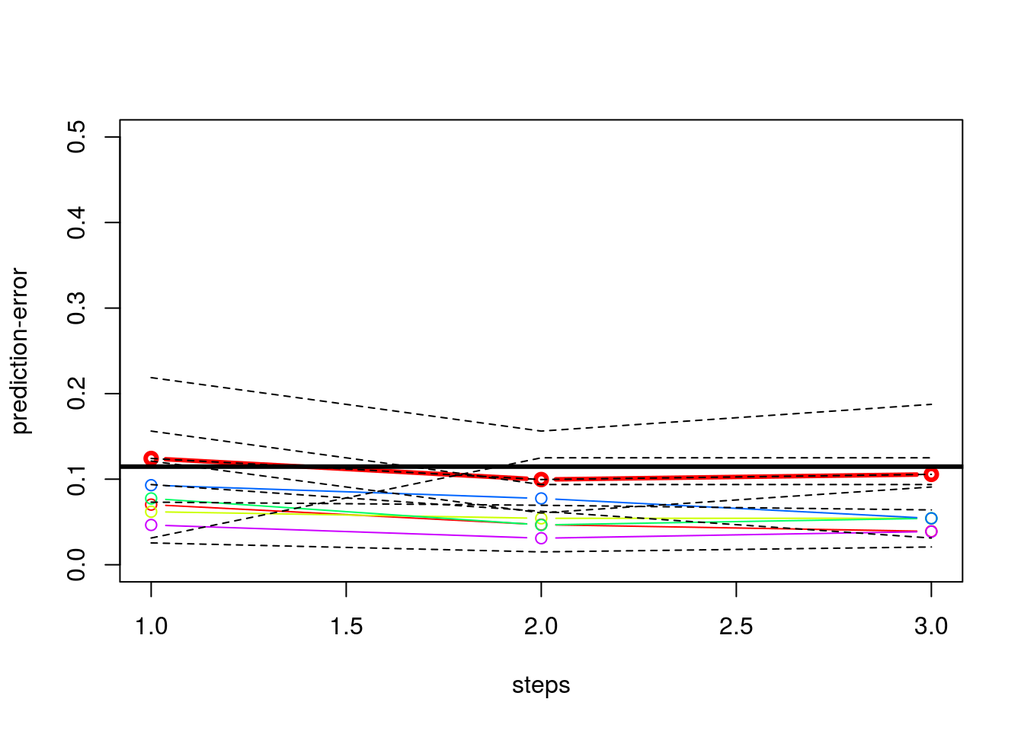

[1] “Prediction error at end is: 0.124242424242424” [2] “Prediction error at end is: 0.0996212121212121” [3] “Prediction error at end is: 0.105681818181818”

| k 1 | k 2 | k 3 | k 4 | k 5 |
| --- | --- | --- | --- | --- |
| crosc_ws11_10m | dtm_hr_CONVEX_r5 | planc_DTM_50m_avg_ws11_50m | Convexity_10m | longc_DTM_50m_avg_ws3_50m |
| maxic_DTM_50m_avg_ws7_50m | planc_DTM_50m_avg_ws5_50m | maxic_DTM_50m_avg_ws3_50m | slope_ws5_hr_hr | longc_ws3_hr_hr |
| profc_DTM_50m_avg_ws11_50m | longc_DTM_50m_avg_ws3_50m | maxic_DTM_50m_avg_ws7_50m | Maximal_Curvature_50m | profc_DTM_50m_avg_ws3_50m |

[1] “OBB error with all predictors of localterrain is 0.062111801242236”

|  | GLD | TG | MeanDecreaseAccuracy | MeanDecreaseGini |
| --- | --- | --- | --- | --- |
| Maximal_Curvature_50m | 0.0072524 | 0.0017013 | 0.0020635 | 0.3293938 |
| profc_ws15_hr_hr | 0.0005000 | 0.0022697 | 0.0020366 | 0.1356346 |
| planc_DTM_50m_avg_ws5_50m | 0.0014000 | 0.0020058 | 0.0019351 | 0.2350381 |
| minic_ws5_hr_hr | 0.0003667 | 0.0017628 | 0.0016384 | 0.0980278 |
| longc_DTM_50m_avg_ws9_50m | 0.0014000 | 0.0017159 | 0.0016325 | 0.2222264 |
| longc_DTM_50m_avg_ws11_50m | 0.0017913 | 0.0014552 | 0.0016147 | 0.3468189 |
| Slope_50m | 0.0113857 | 0.0009209 | 0.0015446 | 0.4067334 |
| maxic_DTM_50m_avg_ws3_50m | 0.0041000 | 0.0014099 | 0.0015432 | 0.6297733 |
| maxic_DTM_50m_avg_ws7_50m | 0.0031333 | 0.0012516 | 0.0014078 | 0.3010130 |
| profc_ws19_hr_hr | -0.0083667 | 0.0019630 | 0.0013627 | 0.1725236 |

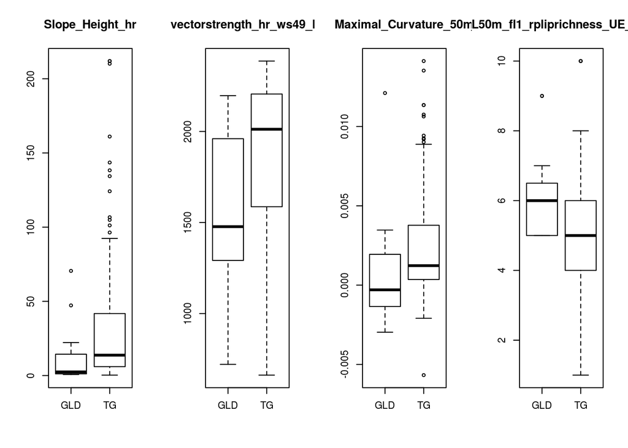

How does this compare to the differences between the units on the geological map?

[1] “OBB error with all predictors of allpreds is 0.0234802187198456”

|  | GLD | TG | MeanDecreaseAccuracy | MeanDecreaseGini |
| --- | --- | --- | --- | --- |
| elev_ws15_10m | 0.0814706 | 0.0070697 | 0.0135824 | 27.262963 |
| elev_ws11_10m | 0.0736616 | 0.0066715 | 0.0125042 | 26.132783 |
| elev_ws3_10m | 0.0774822 | 0.0059069 | 0.0121214 | 27.674571 |
| elev_ws5_10m | 0.0726450 | 0.0059982 | 0.0117233 | 24.415731 |
| Channel_Network_Base_Level_hr | 0.0733302 | 0.0036268 | 0.0096916 | 25.672811 |
| Relative_Slope_Position_50m | 0.0515548 | 0.0040775 | 0.0082086 | 13.868968 |
| Channel_Network_Base_Level_50m | 0.0503830 | 0.0032988 | 0.0073926 | 13.575693 |
| ChannelNetworkBaseLevel_10m | 0.0633524 | 0.0017008 | 0.0070665 | 23.963441 |
| Vertical_Distance_to_Channel_Network_50m | 0.0171934 | 0.0035963 | 0.0048033 | 8.225618 |
| Texture_50m | 0.0403148 | 0.0011823 | 0.0045514 | 12.731855 |

[1] “OBB error with all predictors of roughness is 0.0794212218649518”

|  | GLD | TG | MeanDecreaseAccuracy | MeanDecreaseGini |
| --- | --- | --- | --- | --- |
| vectorruggedness_hr_ws53 | -0.0014389 | 0.0113289 | 0.0101879 | 4.091476 |
| vectorruggedness_hr_ws59 | -0.0005787 | 0.0096371 | 0.0087436 | 4.397573 |
| vectorruggedness_hr_ws51 | -0.0012702 | 0.0091008 | 0.0082024 | 3.908026 |
| vectorruggedness_hr_ws55 | -0.0005277 | 0.0086597 | 0.0078826 | 3.943207 |
| vectorruggedness_hr_ws45 | -0.0008416 | 0.0085202 | 0.0077213 | 3.245262 |
| vectorruggedness_hr_ws57 | -0.0015180 | 0.0085745 | 0.0077008 | 4.049343 |
| vectorruggedness_hr_ws43 | -0.0011482 | 0.0082347 | 0.0074074 | 3.194221 |
| vectorruggedness_hr_ws39 | -0.0029815 | 0.0083933 | 0.0073972 | 2.692645 |
| Texture_50m | 0.0440124 | 0.0036414 | 0.0071600 | 20.381194 |
| vectorruggedness_hr_ws49 | -0.0013523 | 0.0078103 | 0.0070146 | 3.811423 |

[1] “OBB error with all predictors of localterrain is 0.0842443729903537”

|  | GLD | TG | MeanDecreaseAccuracy | MeanDecreaseGini |
| --- | --- | --- | --- | --- |
| slope_DTM_50m_avg_ws11_50m | -0.0004842 | 0.0055868 | 0.0050533 | 8.192058 |
| Slope_10m | -0.0003779 | 0.0054094 | 0.0048924 | 5.734673 |
| slope_ws19_hr_hr | -0.0004701 | 0.0053701 | 0.0048616 | 3.664498 |
| slope_ws11_hr_hr | 0.0015954 | 0.0048380 | 0.0045627 | 4.418553 |
| slope_ws5_10m | -0.0005203 | 0.0049050 | 0.0044284 | 4.280049 |
| slope_DTM_50m_avg_ws9_50m | -0.0000460 | 0.0048270 | 0.0043967 | 7.421158 |
| slope_ws13_hr_hr | -0.0003798 | 0.0047733 | 0.0043345 | 4.298590 |
| slope_ws3_10m | 0.0001157 | 0.0047221 | 0.0043200 | 4.623618 |
| slope_ws15_hr_hr | -0.0011953 | 0.0047762 | 0.0042553 | 4.344442 |
| slope_ws23_hr_hr | -0.0004692 | 0.0044909 | 0.0040555 | 4.413137 |

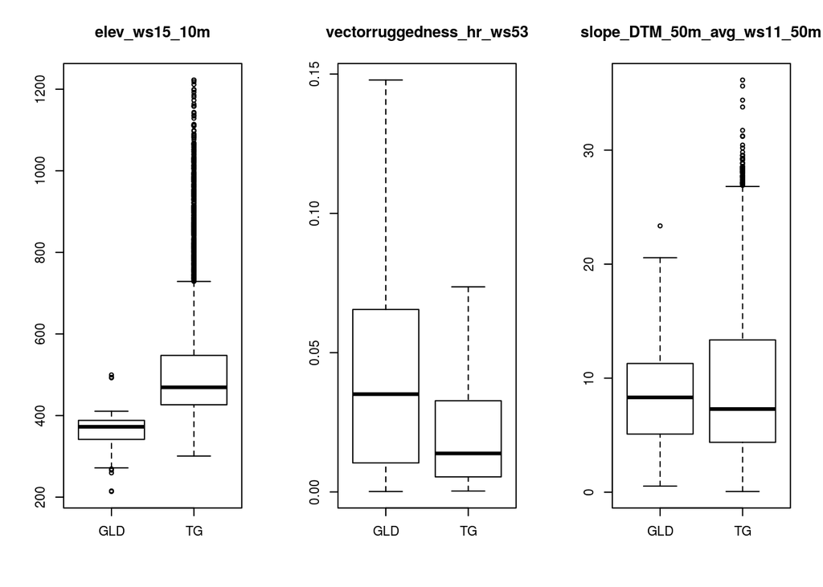